# What Drives Demand for Playlists on Spotify?

Converted from PDF `Pachali-SpotifyPlaylistDemand-2025-MKSC.pdf` · 12 pages · anchors: page `#pN`, block `#pN-bK`

Page 1

[figure not shown]

NOTE: figure/graphic rendered as an image from the PDF; its content is not machine-readable text. Caption (if any) follows as the next block.

**text found inside the figure**

Marketing Science

Publication details, including instructions for authors and subscription information: http://pubsonline.informs.org

What Drives Demand for Playlists on Spotify?

Max J. Pachali, Hannes Datta

To cite this article: Max J. Pachali, Hannes Datta (2025) What Drives Demand for Playlists on Spotify?. Marketing Science 44(1):54-64. https://doi.org/10.1287/mksc.2022.0273

This work is licensed under a Creative Commons Attribution-NonCommercial 4.0 International License. You are free to download this work and share with others for any purpose, except commercially, and you must attribute this work as “*Marketing Science*. Copyright © 2024 The Author(s). https://doi.org/10.1287/mksc.2022.0273, used under a Creative Commons Attribution License: https://creativecommons.org/licenses/by-nc/4.0/.”

Copyright © 2024 The Author(s)

Page 2

### **What Drives Demand for Playlists on Spotify?**

#### **Max J. Pachali,<sup>a,</sup>* Hannes Datta<sup>a</sup>**

[figure not shown]

NOTE: complex table shown as an image of the PDF; the text below is a rough machine extraction and may be mis-aligned.

**extracted text (unreliable layout)**

**1. Introduction** Digital platforms have increasingly replaced traditional revenue streams across various industries, including music, where streaming platforms now account for 84% of total revenues in the United States (Friedlander and Bass 2023). Users seeking to consume music can either search for particular songs or albums or browse thou sands of playlists—that is, curated lists of songs centered around a specific genre, mood, activity, event, or artist. Playlists have contributed to a significant expansion in music consumption on streaming services (Datta et al. 2018), accounting for about 30% share of listening time on Spotify. Another 30% of music consumption is from tracks saved in users’ music libraries (Spotify 2018), which often get discovered by consumers via playlists. Many of the most popular playlists are designed and professionally managed by Spotify. With 15,000 play lists, Spotify attracts 63% of platform-wide playlist fol lowers (Aguiar and Waldfogel 2021). Other playlists on the platform are either curated by users or professional

editors—including major and independent music labels. Finally, Spotify features some playlists across various categories on the Spotify app’s Search Page. This chang ing directory of lists features mostly playlists designed internally by Spotify.

Despite the growing importance of playlists to music consumption, not much is known about why users pre fer some playlists over others. For example, users may follow playlists because they are prominently featured on the platform, giving them a shortcut to finding music they want to listen to from Spotify’s vast assortment. Alternatively, users may follow playlists because they contain tracks by famous artists such as Taylor Swift (Universal), Adele (Sony), or Ed Sheeran (Warner). In our empirical analysis, we compare how adding tracks from popular major label artists to a playlist causally affects daily playlist followers in the short term (i.e., using variation within a month) versus the impact of the playlist being featured on the Search Page of the Spotify app. Before our work, little was known about how

54

#### **MARKETING SCIENCE Vol. 44, No. 1, January–February 2025, pp. 54–64**

#### **ISSN 0732-2399 (print), ISSN 1526-548X (online) https://pubsonline.informs.org/journal/mksc**

Page 3

strongly users respond to these drivers of playlist demand.<sup>1</sup>

We use two complementary methods to estimate these effects: a two-way fixed effects model (Shapiro et al. 2021) and a synthetic difference in difference model (Arkhangelsky et al. 2021). Our analysis builds on a unique data set collected from *Chartmetric.com* that tracked more than 30,000 playlists across 66 music cate gories between October 2019 and March 2020. The data include the number of daily aggregate playlist followers, as well as various characteristics such as whether play lists add tracks from famous artists of the three major record labels (Universal, Sony, and Warner), the share of content on the playlist owned by these labels, the dura tion of the playlist, and the acoustic attributes of tracks (Boughanmi and Ansari 2021). Our data set also records which playlists were featured prominently on the plat form’s Search Page on a given day, obtained through live scraping from everynoise.com/worldbrowser.cgi (Boegershausen et al. 2022).

Our identification strategy relies on the synthetic dif ference in difference (SDID) method to estimate treat ment effects (e.g., the effect of featuring playlists on the Search Page) relative to control playlists that closely mimic treated playlists but that have not received the treatment (Berman and Israeli 2022). For this purpose, the SDID method reweighs the large pool of control playlists to match pre-exposure trends between treated and control observations, reducing the reliance on paral lel trend assumptions as in conventional difference in difference approaches (Arkhangelsky et al. 2021). We also infer treatment effects in a flexible two-way fixed effects (2W-FE) model accounting for date and playlist- month fixed effects (Shapiro et al. 2021). We find that the treatment effects are consistent between the SDID and 2W-FE models, demonstrating robustness with regard to different model specifications and assumptions.

Our SDID estimates reveal that users strongly value playlists featured in the Spotify app, implying that daily followers go up by 0.95% if a playlist is included on the Search Page. For large playlists like “Reggaeton Classic” (which has 1.9 million followers), being prominently fea tured on the Spotify app can yield 18,050 additional daily followers. This finding indicates that Spotify is effective in guiding consumer searches of its vast playlist assortment through what it features on its Search Page. In comparison, we find that users are about half as sensi tive to the inclusion in a playlist of tracks by popular major label artists—adding at least one track by a major label superstar artist increases daily followers by 0.45%.

Our analysis of playlist demand has two main implica tions. First, our estimates show that playlist curators attract followers twice as easily when their list is featured on the Search Page as when they add a track by a major label superstar. Historically, the major music labels controlled content distribution in the music industry and

exerted influence over how music was advertised and sold offline (du Gay and Negus 1994, Prey 2020). Today, however, our findings corroborate researchers’ observa tions that music streaming platforms have higher in fluence over users’ listening behavior compared with labels—such as by promoting songs via playlists to the advantage of some producers over others (Aguiar and Waldfogel 2021).

Second, our results imply that superstar artists remain a relevant asset for major music labels. This insight is of interest to record labels and music streaming platforms, who are disputing royalty rates in the United States.<sup>2</sup>

Our findings could aid judges in assessing the consumer value of major label content on music streaming plat forms: the inclusion of major label superstar tracks in playlists draws significant attention, as reflected by its positive (short-term) effect on followers.

The rest of the paper is organized as follows. Section 2 presents the data. Section 3 discusses causal identifica tion challenges and presents two model specifications that address these challenges: the two-way fixed effects model and the synthetic difference in difference model. Section 4 presents the treatment effect estimates and dis cusses robustness checks. We offer concluding thoughts and discuss the implications of our results in Section 5.

**2. Data 2.1. Data Set Construction** Our data set covers 34,483 playlists on Spotify from vari ous professional curators, including the platform, and major and independent music labels. We created this data set using the API of Chartmetric.com, a platform that tracks the composition (i.e., which songs are avail able on a list at any point in time) and performance (e.g., daily followers) of playlists available on Spotify.

We initially obtained a list of all 1.2 million playlists tracked by Chartmetric in April 2020. This cross- sectional data set includes playlist IDs and names (e.g., “Happy Tunes”), curator names (e.g., “Spotify”), tag words describing a playlist’s content, and followers at the time of data retrieval. We group playlist curators as per the classification in Online Appendix A. In addition to the cross-sectional characteristics, we obtained daily data on a playlist’s number of followers from October 2019 to March 2020, along with information on which song was available on a list and when.<sup>3</sup>

To understand which type of songs are included on playlists, we parse comprehensive track-level meta- information of about 2 million tracks. For each track, we observe its duration (in minutes), release date, and record label. We further classify whether each track is (1) distributed by one of the major record labels (Uni versal, Sony, or Warner)<sup>4</sup> and (2) released by popular “superstar” artists, based on historical top 10 place ments in the Billboard Charts (Top 100; 1999–2019) and

**Pachali and Datta:** *What Drives Demand for Playlists on Spotify?* Marketing Science, 2025, vol. 44, no. 1, pp. 54–64, © 2024 The Author(s) 55

Page 4

Spotify Charts (Top 200; 2016–2019).<sup>5</sup> We report sum mary statistics on these measures in Table B1 in Online Appendix B. Collectively, the major music labels account for most of the superstar content on the plat form (6,000+ tracks). Tracks by these popular artists are also added to more playlists compared with the remain ing artists on the platform. Our data contain numeric measures characterizing the tracks’ acoustic attributes (as in Boughanmi and Ansari (2021), i.e., danceability, energy, speechiness, acousticness, instrumentalness, live ness, valence, tempo, loudness). We aggregate this infor mation to the playlist level by computing a weighted average of the attributes at every date.<sup>6</sup>

We next augment the data with daily information about which playlists are featured on the Search Page of the Spotify app. Figure 1 illustrates featured playlists in the “Focus” category. Everynoise.com makes the playlists featured on Spotify’s Search Page available in real-time across up to 50 categories and 49 countries. To capture daily fluctuations in featured playlists, especially considering our data’s global coverage, we scraped this website at three-hour intervals between October 2019 and March 2020 (Boegershausen et al. 2022). Our raw data record a timestamp, the name of the category, the country name, and a list of playlist IDs featured in a category and country at the time of data retrieval. Most categories on the Search Page per tain to established genres (e.g., “pop,” “rock,” “jazz,” “EDM”). Other categories are relatively new, such as activity categories (e.g., “sleep,” “workout”) or mood categories (e.g., “inspirational”). Categories are largely the same across countries, but featured playlists may differ based on users’ location. Playlists can therefore be featured in multiple categories and countries simultaneously.

As Spotify does not provide a categorization for all of its playlists, we developed our own categorization based

on association rule mining (Hastie et al. 2009), which aligns with the categories observed on Spotify’s Search Page. Tracks are added to or removed from playlists, and the character of a playlist—and consequently, its competitors—can change. To account for the dynamic nature of a playlist’s content, we allow for weekly cate gory changes. The largest category is “pop” (3,979 play lists with combined followers of 336 million), followed by “hiphop+pop,” a hybrid category consisting of both “hiphop” and “pop” tracks (281 million followers). We provide an overview of the top 20 categories and details on the categorization algorithm in Online Appendix C.

**2.2. Descriptive Statistics** Table 1 shows how playlist followers differ across cura tors, shown for the estimation sample of 34,483 playlists (left panel), as well as the entire sample of 1.2 million playlists (right panel). Spotify’s editorial playlists are the most popular playlists, attracting 70% of the audience. The platform’s nonpersonalized editorial playlists (3, 042) account for 33% of followers. Semipersonalized edi torial playlists (1, 525), on which different users see a dif ferent subset of a predetermined set of master tracks, account for 26% of followers. Spotify’s “This is” playlists (1,639) focus on a single artist’s content and account for 11% of followers. On the other hand, the three major labels account for 2,522 playlists and a combined fol lower share of only 5%. The differences in the aggregate follower share across playlist curator groups are negligi ble between selected playlists in the estimation sample and all the 1.2 million playlists.

[figure not shown]

NOTE: figure/graphic rendered as an image from the PDF; its content is not machine-readable text. Caption (if any) follows as the next block.

In Table 2, we compare playlists that add at least one major label superstar track during our observation period to those that do not. On average, major label superstars appear on playlists that have more followers and are updated more frequently. These playlists, typi cally not curated by Spotify, feature a higher proportion of major label content and shorter tracks. This evidence is in line with the idea that the pool of exceptionally pop ular artists is a valuable asset of the major labels. Going

**Figure 1.** (Color online) Screenshot of the Search Page in the Spotify app

*Note.* Spotify features selected playlists prominently in the Search Page of the app.

**Pachali and Datta:** *What Drives Demand for Playlists on Spotify?* 56 Marketing Science, 2025, vol. 44, no. 1, pp. 54–64, © 2024 The Author(s)

Page 5

forward, we thus focus on the event of adding a super star artist’s track to playlists in order to measure the impact of major label content on playlist demand on Spotify.

Figure 2 illustrates the featuring activity across catego ries on the Search Page between October 2019 and March 2020. We observed most categories for the entire duration of our study (e.g., “latin,” “roots,” “soul,” and “workout”). Some categories are observed for a shorter period of time (e.g., the category “2019,” featuring play lists celebrating the past year, such as “Your Best 2019 Hits”).<sup>7</sup> The figure underscores that there is substantial featuring activity on Spotify, but categories are rarely updated all at the same time.

Table 3 shows that playlists featured in at least one category on Spotify’s Search Page have substantially more followers than the corresponding group of nonfea tured playlists. Featured playlists also contain slightly less major label content, fewer tracks, and are updated more frequently. Finally, the vast majority of featured playlists are owned and operated by Spotify, which raises concerns that Spotify tends to feature its own

content on the platform (J¨urgensmeier and Skiera 2023). We estimate the effect of featuring playlists on playlist followers to quantify Spotify’s ability to guide consumer attention through the Search Page.

**3. Empirical Strategy and Modeling Approaches** The main goal of our study is to estimate the causal effect of featuring playlists on Spotify’s Search Page and compare it to the effect of adding songs by exceptionally popular major label artists to playlists. We first describe the identification challenges associated with these two primary goals and then present two modeling ap proaches that address these challenges—the two-way fixed effects model and the staggered synthetic differ ence in difference model. All our estimates reflect short- term treatment effects as we are relying on the variation in featuring on the Search Page or adding tracks by major label superstars across weeks within a month. Estimates of the long-term effects on playlist followers of these demand factors goes beyond our data coverage.

**Table 1.** Playlist Followers Differ Across Curators

[output not shown]

NOTE: table converted from PDF layout to HTML text; cell boundaries are reconstructed. See PDF if exact alignment matters.

*Notes.* Reported across the selected sample of 34,483 playlists, and all 1.2 million playlists available at *Chartmetric.com* (April 2020). Curators grouped as per classification in Online Appendix A and shown in descending order of their follower share.

**Table 2.** Characteristics of Playlists Without and with Major Label Superstars

[output not shown]

NOTE: table converted from PDF layout to HTML text; cell boundaries are reconstructed. See PDF if exact alignment matters.

*Notes.* Reported across 34,483 playlists in our main sample, shown for playlists that do not contain tracks by major label superstars (left) versus playlists that contain at least one track by a major label superstar during our observation period. Superstar artists are defined as any artist appearing in the Spotify Top 10 between December 2016 and July 2019, or the U.S. Billboard Top 10 between 1999 and 2019. The table reports the number of playlists, the playlists’ average followers, the share of playlists owned and curated by Spotify (in %), the average share of major label content available on a playlist (in %), the average number of weekly tracks available on a playlist, the probability that a playlist is updated in a given week, and the average track length (in minutes).

**Pachali and Datta:** *What Drives Demand for Playlists on Spotify?* Marketing Science, 2025, vol. 44, no. 1, pp. 54–64, © 2024 The Author(s) 57

Page 6

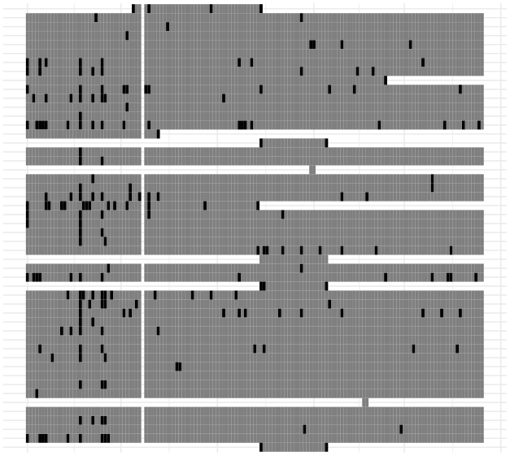

NOTE: figure/graphic rendered as an image from the PDF; its content is not machine-readable text. Caption (if any) follows as the next block.

**3.1. Identification Challenges** The observational nature of the data poses several chal lenges to identifying treatment effects (Berman and Israeli 2022). (i) Every playlist in our data set is either treated in each period (i.e., featured on the Search Page or tracks by popular major label artists being added) or

untreated in each period, and we do not observe the counterfactual outcome in the unobserved condition. (ii) The decision of whether to feature a playlist or add pop ular tracks may be endogenous in the sense that it may be correlated with Spotify’s or the focal curators’ expec tations about changes in demand for the playlist. For

**Figure 2.** Availability and Updates of Different Categories on the Search Page

Yoga Workout

Word Travel Student Spotify Awards

Soul Sleep Sessions

Roots Romance

Rock Reggae R&B Punk Pop Culture

Pop Party Nature Sounds

Mood Metal Meditation

Latin K−Pop

Jazz Inspirational Indie/Alternative

Holidays

Hip Hop

Gaming

Funk Fresh Start

Focus Family Exercise

Ellen Edm/Dance

Dinner

Desi Decades

Country Comedy Classical

Chill Blues Black History Month

Arab Anime

Afro 2019

Nov 2019 Dec 2019 Jan 2020 Feb 2020 Mar 2020 Apr 2020 Date

Category on Spotify's Search Page

*Notes.* We illustrate the availability of different categories on the Search Page during our observation period in gray. Updates (i.e., additions or removals of playlists) within categories on the Search Page are reported in black. The figure underscores that there is substantial featuring activ ity on Spotify.

**Table 3.** Characteristics of Featured and Nonfeatured Playlists

[output not shown]

NOTE: table converted from PDF layout to HTML text; cell boundaries are reconstructed. See PDF if exact alignment matters.

*Notes.* Reported across 34,483 playlists in our main sample, shown for playlists are featured at least once (versus never featured). The table reports the number of playlists, the playlists’ average followers, the share of playlists owned and curated by Spotify (in %), the average share of major label content available on a playlist (in %), the average number of tracks available on a list in a week, the likelihood that a playlist is updated in a given week, and the average track length (in minutes).

**Pachali and Datta:** *What Drives Demand for Playlists on Spotify?* 58 Marketing Science, 2025, vol. 44, no. 1, pp. 54–64, © 2024 The Author(s)

Page 7

example, Spotify may add more of its own playlists to the Search Page to counteract (amplify) periods of natu rally low (high) demand. Relatedly, playlist curators may add tracks by extremely popular major label artists to correct a downward move in followers. (iii) Playlists are added to the Search Page or tracks by popular major label artists are added at different times, requiring care ful computation and aggregation of treatment effects (Baker et al. 2022). (iv) Spotify or other curators could have implemented other strategies concurrently when featured on the Search Page or having added “super star” tracks, and we might not be able to separate the effect of concurrent changes from featuring or major label track addition. (v) There may be spillovers between treated and nontreated playlists within the same cate gory, potentially violating the stable unit treatment value assumption (Goldfarb et al. 2022).

**3.2. Two-Way Fixed Effects Model** The first approach models the main drivers of playlist followers in a reduced-form log-linear demand model, similar to in Shapiro et al. (2021). The proposed research design requires fewer assumptions compared with a structural demand model using aggregate data (Berry 1994) and is suitable for our main goal of comparing the effect of featuring playlists on Spotify’s Search Page with the effect of adding tracks by popular major label artists to playlists.<sup>8</sup> Moreover, as the proposed model is parsi monious, it allows us to flexibly include characteristics of the main competitor playlists in the same category (leveraging the dynamic categorization derived in On line Appendix C). We specify the two-way fixed effects model as follows:

+ η<sup>star</sup> Treated<sup>star</sup>

+ ω log(*rC*(*p*), *t* + *k*) + φ<sup>′</sup>*xpt* + ψ<sup>′</sup>*xpt* + ε*pt*, (1)

**equation / math rendering (image)**

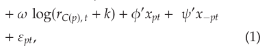

NOTE: contains mathematical notation; text above is the PDF text layer and symbols may be mis-extracted. Image shows the original.

where *fpt* measures the followers of playlist *p* on day *t*.<sup>9</sup>

The coefficients η*<sup>feat</sup>*and η*<sup>star</sup>*measure the effect of including playlists on Spotify’s Search Page, as well as the effect of adding at least one track by a highly popular major label artist (“superstar”) to playlists on day *t*, where Treated<sup>feat</sup>

The second line in Equation (1) accounts for various control terms. β controls for the effect of including major label tracks on the playlist, beyond those from exception ally popular superstars, where *mlpt* measures the share of major label tracks on playlist *p*; ω measures the effect

of personalized recommendations in category *C*(*p*) at date *t* on the followers of playlist *p*;<sup>10</sup> and φ<sup>′</sup>*xpt* controls for the average track age, playlist duration (in hours), as well as acoustic attributes of playlist *p*, whereas ψ<sup>′</sup>*xpt* controls for featuring on the Search Page and availability of superstar tracks of the 15 largest competing playlists in the same category. Including the rich control variables in Equation (1) is important to address identification concern (iv) and ensure that the estimated treatment effects are not confounded with simultaneously occur ring changes in other playlist covariates.

Figure D1 in Online Appendix D shows the residual identification variation in featuring (left panel) and addi tions of tracks by major label superstars (right panel) after accounting for playlist-month fixed effects and remaining control variables as in Equation (1). There is sufficient variation in both variables left that is caused by Spotify updating its Search Page (Figure 2) and play list curators adding tracks by major label superstar artists within weeks of a month.<sup>11</sup>

The two-way fixed effects model assumes that condi tional on the rich fixed effects and control variables, the residual variation in Figure D1 is quasi-random—that is, not correlated with unobserved demand factors. To jus tify this assumption, one might argue that user demand for a playlist does not drastically change within a month. Hence, variations in the composition of the playlist’s songs and the Search Page are quasi-random within weeks of a month. However, we cannot observe the sta bility of users’ preferences for playlists, and Spotify may update its playlists/Search Page in response to demand shocks within a month. In other words, the main limita tion of this model pertains to the identification challenge (ii) as there might be endogenous selection of remaining playlists into the treatment and control groups, even conditional on including playlist-month fixed effects. To address this concern, we would ideally want to create a control group of playlists that closely resemble treated playlists in the days before the event but do not get trea ted in our data.<sup>12</sup> Another potential issue with the two- way fixed effects model is that it does not adequately account for the different timing of treatment effects (challenge iii), potentially biasing estimation results if treatment effects can change over time (“dynamic treat ment effects”) due to a “bad comparisons” problem (Baker et al. 2022). To mitigate these limitations, we pro pose an alternative model.

**3.3. SDID** To investigate whether—and if so, by how much—the two-way fixed effects specification (Equation (1)) biases treatment effect estimates, we use the synthetic differ ence in difference model (Arkhangelsky et al. 2021). By weighting the observations of never-treated playlists to generate “clones” of the treated observations, this method improves on our identification strategy about

**Pachali and Datta:** *What Drives Demand for Playlists on Spotify?* Marketing Science, 2025, vol. 44, no. 1, pp. 54–64, © 2024 The Author(s) 59

Page 8

the endogenous selection into treatment and control groups (challenge ii). Moreover, we account for identifi cation challenge iii—the differential treatment timing— by repeatedly applying the SDID estimator on the subset of data implied by unique adoption dates, as recom mended in Arkhangelsky et al. (2021).

The SDID’s crucial “exclusion restriction” assumption is that the synthetic control playlists precisely match the follower evolution of the treated playlists in the times before the event.<sup>13</sup> Treating a playlist can then be regarded as quasi-random compared with its synthetic control unit. To justify this assumption, we present the mean squared percentage error (MSPE) between the treated playlist’s followers and the synthetic control playlists over the 15days prior to the event, detailed in Table 4. The small MSPE highlights a strong fit, facili tated by leveraging thousands of never-treated donor units to generate synthetic “clones” for treated playlists. There are two potential challenges (iv and v) to this exclusion restriction assumption that we address as fol lows. First, Spotify or other curators may have concur rently implemented other changes after treatment (identification challenge iv). We checked the stability in playlists’ characteristics after treatment in Table E1 in Online Appendix E. We found that curators changed almost none of the covariates after their playlists got fea tured on the Search Page or tracks by exceptionally pop ular major label artists were added. Second, we use only donor playlists from categories other than the treated units to ensure that the stable unit treatment value assumption is not violated (Goldfarb et al. 2022).

**3.3.1. Playlist Featuring.** We use data on all playlists we observed being featured for the first time. To have sufficient pretreatment data, we require playlists to have been observed not featured for at least two weeks. We retain observations 15days before and 15days after treatment and require that playlists remain treated in the after-period for at least 7days. Choosing such a narrow analysis window mitigates the impact of confounding variables (Orhun et al. 2016). These steps led to a sample of 113 treated playlists on 23 unique dates.

Featured observations include more popular playlists such as “Reggaeton Classics” (1.9 million followers), as well as less popular playlists such as “Tech House Chargers” (4.5k followers). Most of the featured playlists were curated by Spotify, indicating that Spotify tends to prefer selecting its own playlists for inclusion on the Search Page.<sup>14</sup> Figure D2 in Online Appendix D illustrates the variation in treatment dates across treated playlists. In line with Figure 2, we see that playlists were included on many different dates during our observation period.

**3.3.2. Addition of Tracks from Popular Major Label Artists.** We define the treatment as adding at least one track to a playlist by a major label “superstar” artist

included in the Spotify Top 10 between December 2016 and July 2019, or the U.S. Billboard Top 10 between 1999 and 2019. Artists include established superstars such as Alicia Keys, Jennifer Lopez, and Ed Sheeran, as well as more recent superstars such as Shawn Mendes, Billie Eil ish, and Lizzo. Again, we keep treated playlists that are observed at least 15days before and 15days after treat ment, with the requirement that newly added tracks be listed for at least 7days after the event. It is possible that playlists can be “treated” multiple times; in these few cases, we select only the first treated event of a playlist (under the restriction that the second treatment did not happen in the 15days after the first treatment). These steps lead to a sample of 2,248 treated playlists on 107days. Figure D3 in Online Appendix D shows the treatment variation plot for the selected events.

**3.3.3. Econometric Specification.** Conditional on every treatment date *a* ∈*A*, we have a balanced panel with *Pco*,*a* never-treated control playlists and *Ptr*,*a* treated playlists that get exposed after *Tpre*  15 and are ob served for *Tpost*  15 consecutive time periods, with *Pa*  *Pco*,*a* + *Ptr*,*a* and *T*  *Tpre* + *Tpost*. We follow Arkhangelsky et al. (2021) and estimate the average causal effect of exposure for batch *a* in a two-way fixed effects model:

 arg min

η<sup>con</sup>,*µ*,γ*p*,γ*t*

NOTE: contains mathematical notation; text above is the PDF text layer and symbols may be mis-extracted. Image shows the original.

*p*1

**equation / math rendering (image)**

NOTE: contains mathematical notation; text above is the PDF text layer and symbols may be mis-extracted. Image shows the original.

X *T*

**equation / math rendering (image)**

NOTE: contains mathematical notation; text above is the PDF text layer and symbols may be mis-extracted. Image shows the original.

*t*1

**equation / math rendering (image)**

NOTE: contains mathematical notation; text above is the PDF text layer and symbols may be mis-extracted. Image shows the original.

)

**equation / math rendering (image)**

NOTE: contains mathematical notation; text above is the PDF text layer and symbols may be mis-extracted. Image shows the original.

, (2)

where <sup>˜</sup>*f pt*  log(*fpt* + *k*), con ∈{feat,star}, ˆω*p*,*a* are weights aligning pre-exposure trends in log-followers of never- treated units with those of treated units, and <sup>ˆ</sup>λ*t*,*a* are time weights balancing pre-exposure time periods with post exposure ones.<sup>15</sup> Because of our staggered adoption set ting, we apply algorithm 1 in Arkhangelsky et al. (2021) on every of the |*A*| balanced panel data sets. We compute the aggregate treatment effect as the average effect across all event dates weighted by the event date-specific number of treated playlists (Arkhangelsky et al. 2021).<sup>16</sup>

**4. Estimation Results 4.1. Short-Term Elasticity Estimates** Table 4 summarizes the estimation results. Columns (1) and (2) compare the short-term effects of including play lists on Spotify’s Search Page using the two-way fixed effects model (Equation (1)) and the synthetic difference in difference model (Equation (2)). The small MSPE shows that pre-exposure observations in the control groups align closely with the pre-exposure observations of log-followers of treated playlists, confirming the accu racy of the synthetic control method’s pretreatment matching performance. According to the synthetic

**Pachali and Datta:** *What Drives Demand for Playlists on Spotify?* 60 Marketing Science, 2025, vol. 44, no. 1, pp. 54–64, © 2024 The Author(s)

Page 9

difference in difference estimator in column (2), being included on Spotify’s Search Page increases daily fol lowers by 0.95% on average.<sup>17</sup> This number seems sub stantial given that the average number of followers on featured playlists equals 295,762, implying 2,810 addi tional followers for the average playlists being featured on the Search Page on any day. For larger playlists like “Reggaeton Classic” (which has 1.9 million followers), our estimates imply that being featured on the Search Page typically yields 18,050 additional daily followers.

Columns (3) and (4) in Table 4 compare the estimated treatment effects of adding tracks by exceptionally famous major label superstars. As with being featured on the Search Page, we find that the estimated treatment effects are very close to each other in the two-way fixed effects and the synthetic difference-in-difference models. We find that adding at least one track by a major label superstar increases the daily playlist followers by 0.45% on average. These additional followers can either be gen erated through a higher chance of discovering the trea ted playlist if users search for famous artists on Spotify or by users directly observing the change in the content of the treated playlist. Although adding exceptionally popular major label content positively affects the num bers of followers, the results in Table 4 imply that the treatment effect of featuring playlists on the Search Page is about twice as big.

We also investigated how the increase in the overall share of major label tracks (beyond just including excep tionally popular content) affects playlist followers, as illustrated in Table F1 in Online Appendix F. We find that marginally increasing the coverage of tracks by major label artists does not significantly affect playlist followers (0.0007, *p*  0.81). This finding suggests that, in the short term, the three major record labels (Sony,

Universal, and Warner) attract most consumers on Spot ify with tracks by a small number of superstars rather than with tracks from across their broad catalog of artists.

**4.2. Robustness Checks** We performed additional analyses to provide robustness of our empirical estimates. First, we have dropped the “2019” category celebrating hits of the past year for esti mating the effect of being featured on the Search Page. However, variations in other categories might also be implemented by Spotify in response to seasonality in demand (such as playlists being featured in the “Exercise” or “Yoga” categories at the beginning of the year when users make New Year’s resolutions). We removed these seasonal categories from the data and re-estimated all models. As shown in Table G1 in Online appendix G, the elasticities for the SDID specification are almost identical. The 2W-FE estimate drops after remov ing potentially seasonal categories but is not statistically different from the overall 2W-FE estimate in Table 4.

Second, we show the robustness of our results with regard to the choice of the stabilization constant (*k*  1). We re-estimated the models using the inverse hyperbolic sine transformation to deal with the problem of zeros in the logarithmic specifications. As can be seen in Table G2 in Online Appendix G, the results are very close to the main results in Table 4.

Third, another concern relates to the comparability of the SDID and 2W-FE models for the featuring effect: Although the SDID model focuses on first-time treated playlists to avoid overlapping treatment windows, the 2W-FE model relies on the complete data, also including playlists that were featured multiple times on Spotify’s Search Page. To compare these models on more “equal

**Table 4.** Model Estimates

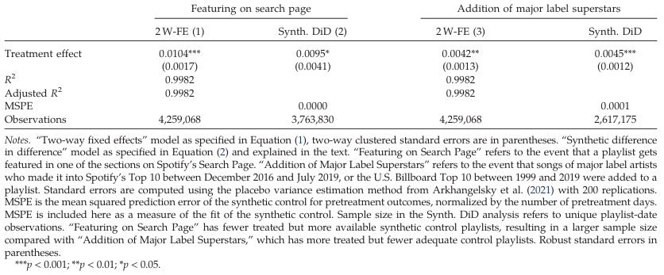

NOTE: complex table shown as an image of the PDF; the text below is a rough machine extraction and may be mis-aligned.

**extracted text (unreliable layout)**

**Pachali and Datta:** *What Drives Demand for Playlists on Spotify?* Marketing Science, 2025, vol. 44, no. 1, pp. 54–64, © 2024 The Author(s) 61

Page 10

footing,” we re-estimated the 2W-FE model, removing playlists before their second treatment date. As can be seen in Table G3 in Online Appendix G, the estimated effect of featuring on the Search Page is virtually the same (0.01045 for the entire data, and 0.01057 for the first-time-only data).

**5. Summary and Discussion** We collected a diverse panel data set covering 30,000+ popular playlists on Spotify to estimate the causal treat ment effect of featuring playlists on Spotify’s Search Page and compare the impact of being featured on this high- traffic page with the effect of adding tracks by popular major label superstar artists to playlists. We find that users are responsive to the featuring of playlists, and our estimates suggest that inclusion on Spotify’s Search Page raises daily followers by 0.95%. For large playlists like “Reggaeton Classic” (with 1.9 million followers), this implies an increase of 18,050 additional daily followers after being featured in Spotify’s app. By comparison, we find the effect of including tracks by popular major label superstars in a playlist to be 0.45%. Our analysis reveals that the average treatment effect of a playlist being fea tured is about two times greater than the effect of adding a track by a “superstar” major label artist to the list.

Our work has important implications for policy makers and music industry professionals. First, as major music labels have watched their market share on music streaming services erode in recent years, some music executives have started to wonder about the value of their “superstar” artists.<sup>18</sup> However, our research sug gests that “superstars” continue to create value on music streaming services: consumers respond to adding major label superstars with an estimated increase in daily fol lowers of 0.45% in the 15days after the event. This find ing is of interest to record labels who are disputing royalty rates with streaming platforms in the United States.<sup>19</sup> Our findings can also aid court judges in asses sing the consumer value of major label content on music streaming platforms like Spotify.

Second, we measure the short-term treatment effect of including playlists on the Search Page, a gateway to the app’s content where a select number of playlists— typically Spotify-curated playlists—are brought to the user’s attention. Our finding that followers increase by 0.95% implies that Spotify is effective in guiding user attention by selectively highlighting playlists on the plat form (Goldfarb and Tucker 2019). Importantly, the fact that the featuring effect is about twice the size of the superstar effect suggests the success of Spotify playlists is much less dependent on the availability of artist- specific (superstar) tracks than it is to being prominently featured on the platform. We believe this difference in effect may in the future drive record labels to pay Spotify to be prominently featured.<sup>20</sup>

To foster competition among playlist curators, policy makers could legally impose a minimum fraction of non-Spotify playlists that need to be featured on the plat form’s Search Page on a given day. Spotify already fea tures its own curated playlists in almost 90% of cases (Table 3). A policy requiring Spotify to feature a mini mum percentage of non–Spotify-curated playlists would be analogous to recently implemented EU legislation requiring streaming services like Apple TV+ and Netflix to feature at least 30% European content or face a European Union customer block.<sup>21</sup>

Our work opens several avenues for inquiry about the economics of streaming. First, our data does not incorpo rate information on all potential factors influencing users’ demand for playlists, such as “announcements” to adver tise playlists or concerts on Spotify. Second, we study playlist followers but lack sufficient data on a playlist’s number of listeners. Third, the results extend to the set of 30,000+ most popular playlists on the platform. How ever, a larger sample of playlists would allow for a better understanding of how Spotify can exert power over music labels through algorithmic design. Fourth, our data primarily allows us to identify short-term treatment effects. Yet, for music labels, understanding the long-term dynamics of a playlist’s follower evolution is important to develop successful playlist brands. For policymakers, in turn, long-term estimates would enable a more nuanced understanding of the power dynamics between digital platforms and their suppliers to devise effective regulatory policies.

**Acknowledgments** Both authors contributed equally to the paper. The authors are grateful for comments from seminar and conference parti cipants at the University of Chicago Booth School of Business, University of Tuebingen, University of Cologne, Goethe Uni versity Frankfurt, Amsterdam Business School, Bocconi Uni versity, KU Leuven, London School of Economics, Stockholm School of Economics, University of Rochester, University of Zurich, Virtual Quant. Marketing Seminar, EMAC 2021, Mar keting Science 2021, Music Economics 2022, and the 12th Tri ennial Invitational Choice Symposium at INSEAD. The paper benefited from comments and discussions with Luis Aguiar, Khaled Boughanmi, Lachlan Deer, Jean-Pierre Dub´e, Dean Eckles, Avery Haviv, Guenter Hitsch, Yufeng Huang, David Holtz, Sanjog Misra, Thomas Otter, Bradley Shapiro, and Andrey Simonov. The authors thank Andrea Antonacci and Roy Klaasse Bos for excellent research assistance.

#### **Endnotes**

**1** Prior related work has explored consumption patterns on digital media, including live streaming (Lin et al. 2021, Lu et al. 2021) and on-demand streaming services (Datta et al. 2018, Wl¨omert et al. 2024). In addition, researchers have measured the market power of digital platforms (Rysman 2009, Song 2021, Franck and Peitz 2023). In the context of music streaming, for example, Aguiar et al. (2021) show that Spotify likely exercises its power to make curation

**Pachali and Datta:** *What Drives Demand for Playlists on Spotify?* 62 Marketing Science, 2025, vol. 44, no. 1, pp. 54–64, © 2024 The Author(s)

Page 11

decisions for the “New Music Friday” playlist favor independent record labels and, to a lesser extent, female artists.

**2** See case docket *19-CRB-0005-WR* at the Copyright Royalty Board, available at https://app.crb.gov/, accessed March 5, 2024.

**3** We rely on *followers* as our metric for measuring playlist demand, in line with the notion that playlist editors aim to increase follower reach. Playlist *listeners* are unavailable for many unpopular and some popular playlists. Playlist followers and listeners correlate strongly (ρ  0.70).

**4** To identify these major labels from thousands of unique labels and their subsidiaries, we use a regular expression–based matching algorithm derived from a list of major label names and associated subsidiaries (Boughanmi and Ansari 2021).

**5** We extract these data from https://www.kaggle.com/datasets/ danield2255/data-on-songs-from-billboard-19992019.

**6** We use as weights the track’s overall popularity in our sample, proxied as the logarithm of each track’s median number of weekly playlist listings in our sample.

**7** As demand might be naturally high for such playlists, indepen dent of inclusion on the Search Page, we removed playlists from the “2019” category from the estimation sample. In a robustness check, we also removed other potentially seasonal categories such as “Holidays” or “Exercise.”

**8** For example, nested logit models may impose restrictive substitu tion patterns (Berry et al. 1995, Bresnahan et al. 1997), and the discrete-choice assumption inherent to structural models of unob served heterogeneity (Berry et al. 1995) is likely violated modeling playlist choice based on followers.

**9** We set the constant to a small number, *k*  1. In a robustness check, we also consider the inverse hyperbolic sine transformation to deal with zero-valued observations (Bellemare and Wichman 2020).

**10** *rC*(*p*),*t* reflects the “recommendation intensity,” defined as the number of songs added to personalized playlists in category *C*(*p*) at date *t*, divided by the number of personalized playlists in category *C*(*p*). Among the user-curated playlists in the raw data, we observe a sample of 1,634 of Spotify’s personalized playlists, such as “Discover Weekly” (60% of all personalized playlists), users’ compi lations of the most listened-to songs from previous years (31%) and “Release Radar” (6%). Personalized playlists are typically private to individual users but can become public when shared on social media.

**11** The median update frequency for an average playlist in our sam ple equals 14 days.

**12** An alternative strategy would be to use instrumental variables to resolve endogeneity concerns. However, it is very difficult to iden tify valid instruments for featuring playlists and including popular superstar tracks in playlists that fulfill the exclusion restriction assumption.

**13** The SDID method compensates for the lack of parallel trends between treated and control playlists by reweighting units to match their pre-exposure trends. This procedure weakens the reliance on parallel trend assumptions as in conventional difference in differ ence methods (Arkhangelsky et al. 2021).

**14** Initially, about 15% of playlists that Spotify featured were from other curators. At the end of November 2019, this share dropped to virtually zero, where it remained for the rest of our sample.

**15** Arkhangelsky et al. (2021) show that the inclusion of unit and time weights makes the estimator more robust and improves precision.

**16** For each adoption date *a* ∈*A*, the variance of the average treat ment effect estimator is computed using the placebo method (algo rithm 4 in Arkhangelsky et al. 2021) using 200 replications. Global

standard errors are given as the square root of the variance of the aggregate treatment effect estimator (Athey and Imbens 2022).

**17** The two-way fixed effects model and the synthetic difference in difference model rely on different assumptions. We find that the estimates of these models, reported in Table 4, are very close to each other. We thus conclude that the potential bias in the two-way fixed effects model due to the staggered setting is small.

**18** See https://www.musicbusinessworldwide.com/as-major-labelmarket-share-falls-on-spotify-can-we-expect-even-more-indie- investment-from-the-big-three/, accessed October 31, 2023.

**19** See case docket *19-CRB-0005-WR* at the Copyright Royalty Board, available at https://app.crb.gov/, accessed March 5, 2024.

**20** Pay-for-play arrangements are already being used by Spotify in other contexts, such as the recently introduced (“Pay For Influ ence”) Discovery Mode that allows artists and record labels to influ ence the algorithm that selects what music is played when users use the streaming platform’s auto-play or personalized radio function. By opting in, record labels agree to be paid a lower royalty rate for streams. This recent development aligns with our results and show cases the dependency of artists (and record labels more broadly) on Spotify’s programming decisions. See https://www.isrc.com/3-Things- To-Know-About-Spotifys-Discovery-Mode.php, accessed May 1, 2023.

**21** See Online Safety and Media Regulation Bill, accessed July 5, 2022.

**References** Aguiar L, Waldfogel J (2021) Platforms, power, and promotion: Evi

dence from Spotify playlists. *J. Industry Econom.* 69(3):653–691. Aguiar L, Waldfogel J, Waldfogel S (2021) Playlisting favorites: Mea

suring platform bias in the music industry. *Internat. J. Industry Organ.* 78:102765. Arkhangelsky D, Athey S, Hirshberg DA, Imbens GW, Wager S

(2021) Synthetic difference-in-differences. *Amer. Econom. Rev.* 111(12):4088–4118. Athey S, Imbens GW (2022) Design-based analysis in difference-in-

differences settings with staggered adoption. *J. Econometrics* 226(1): 62–79. Baker AC, Larcker DF, Wang CC (2022) How much should we trust

staggered difference-in-differences estimates? *J. Financial Econom.* 144(2):370–395. Bellemare MF, Wichman CJ (2020) Elasticities and the inverse

hyperbolic sine transformation. *Oxford Bull. Econom. Statist.* 82(1):50–61. Berman R, Israeli A (2022) The value of descriptive analytics: Evi

dence from online retailers. *Marketing Sci.* 41(6):1074–1096. Berry ST (1994) Estimating discrete-choice models of product differ

entiation. *RAND J. Econom.* 25:242–262. Berry S, Levinsohn J, Pakes A (1995) Automobile prices in market

equilibrium. *Econometrica* 63(4):841–890. Boegershausen J, Datta H, Borah A, Stephen AT (2022) Fields of

gold: Scraping web data for marketing insights. *J. Marketing* 86(5):1–20. Boughanmi K, Ansari A (2021) Dynamics of musical success: A

machine learning approach for multimedia data fusion. *J. Mar keting Res.* 58(6):1034–1057. Bresnahan TF, Stern S, Trajtenberg M (1997) Market segmentation

and the sources of rents from innovation: Personal computers in the late 1980s. *RAND J. Econom.* 28:S17–S44. Datta H, Knox G, Bronnenberg B (2018) Changing their tune: How

consumers’ adoption of online streaming affects music con sumption and discovery. *Marketing Sci.* 37(1):5–21. du Gay P, Negus K (1994) The changing sites of sound: Music retail

ing and the composition of consumers. *Media Culture Soc.* 16(3): 395–413.

**Pachali and Datta:** *What Drives Demand for Playlists on Spotify?* Marketing Science, 2025, vol. 44, no. 1, pp. 54–64, © 2024 The Author(s) 63

Page 12

Franck J-U, Peitz M (2023) Market power of digital platforms.

*Oxford Rev. Econom. Policy* 39(1):34–46. Friedlander JP, Bass M (2023) RIAA mid-year 2023 revenue report.

Accessed March 17, 2024, https://www.riaa.com/wp-content/ uploads/2023/09/RIAA-Mid-Year-2023-Revenue-Report.pdf. Goldfarb A, Tucker C (2019) Digital economics. *J. Econom. Literature*

57(1):3–43. Goldfarb A, Tucker C, Wang Y (2022) Conducting research in mar

keting with quasi-experiments. *J. Marketing* 86(3):1–20. Hastie T, Tibshirani R, Friedman J (2009) *The Elements of Statistical*

*Learning: Data Mining, Inference and Prediction*, 2nd ed. (Springer, Berlin). J¨urgensmeier L, Skiera B (2023) Measuring fair competition on digi

tal platforms. Working paper, Goethe University, Frankfurt, Germany. Lin Y, Yao D, Chen X (2021) Happiness begets money: Emotion and

engagement in live streaming. *J. Marketing Res.* 58(3):417–438. Lu S, Yao D, Chen X, Grewal R (2021) Do larger audiences generate

greater revenues under pay what you want? Evidence from a live streaming platform. *Marketing Sci.* 40(5):964–984.

Orhun AY, Venkataraman S, Chintagunta PK (2016) Impact of com

petition on product decisions: Movie choices of exhibitors. *Mar keting Sci.* 35(1):73–92. Prey R (2020) Locating power in platformization: Music streaming

playlists and curatorial power. *Soc. Media Soc.* 6(2):1–11. Rysman M (2009) The economics of two-sided markets. *J. Econom.*

*Perspective* 23(3):125–143. Shapiro BT, Hitsch GJ, Tuchman AE (2021) TV advertising effective

ness and profitability: Generalizable results from 288 brands. *Econometrica* 89(4):1855–1879. Song M (2021) Estimating platform market power in two-sided mar

kets with an application to magazine advertising. *Amer. Econom. J. Microeconom.* 13(2):35–67. Spotify (2018) Form F-1 registration statement. Accessed July 5,

2022, https://www.sec.gov/Archives/edgar/data/1639920/ 000119312518063434/d494294df1.htm. Wl¨omert N, Papies D, Clement M, Spann M (2024) Frontiers: The

interplay of user-generated content, content industry revenues, and platform regulation: Quasi-experimental evidence from YouTube. *Marketing Sci.* 43(1):1–12.

**Pachali and Datta:** *What Drives Demand for Playlists on Spotify?* 64 Marketing Science, 2025, vol. 44, no. 1, pp. 54–64, © 2024 The Author(s)